# Project A

Mohammed Quasem

### Description

This report will answer the question 2 of project A. The data for this study is from The website FiveThirtyEight published an interactive graphic titled Gun Deaths in America that illustrated the nature of gun deaths for the years 2012 to 2014. The data and code for the project were in a GitHub repo. The data and code was retrieved by Fork and clone placed in this Gun Data repo. *Source of data: Five Thirty Eight*

### Analysis

In this data set, I divided intent into four categories: Accidental, Homicide, Suicide, Undetermined Gender into two categorlies: F, M Race into five categories: Asian/Pacific Islander, Black, Hispanic, Native American/Native Alaskan, White.

*Figure 1. Bar plots with proportion of 2012 subset of intent of gun death* *Intent of Gun Deaths.*

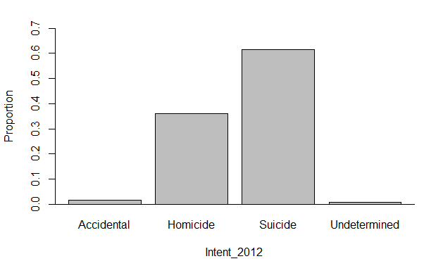

The Intent of gun death in 2012 consists of 1.63% in Accidental category, 36.03% in Homicide category, 61.57% in Suicide category, and 0.76% in Undetermined category.

*Figure 2. Bar plots with proportion of 2012 gun deaths by subset of* *Gender.*

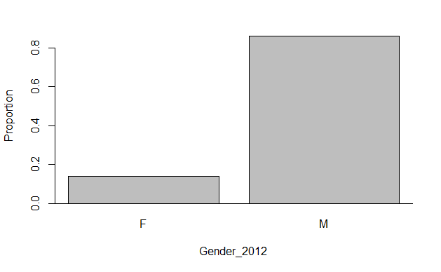

Gender category of gun death consists of 14.08% females and 85.92% males.

*Figure 3. Bar plots with percent of gun deaths in ethnic groups category.*

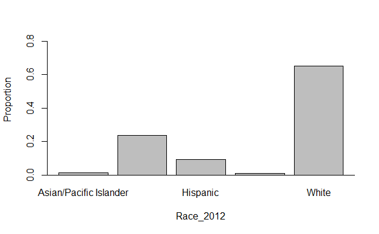

In race category 64.93% white, 23.67% black, 9.12% hispanic, 1.35% Asian/Pacific Islander and 0.92% Native American/Native Alaskan gun deaths took place.

*Figure 4. Bar plots with proportion of 2019 subset of intent of gun death* *Intent of Gun Deaths.*

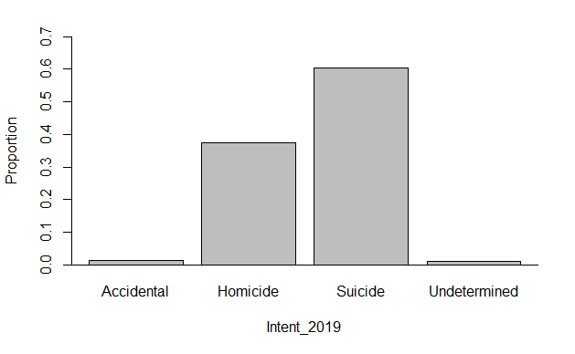

The Intent of gun death in 2019 consists of 1.22% in Accidental category, 37.57% in Homicide category, 60.33% in Suicide category, and 0.87% in Undetermined category.

*Figure 5. Bar plots with proportion of 2019 gun deaths by subset of* *Gender.*

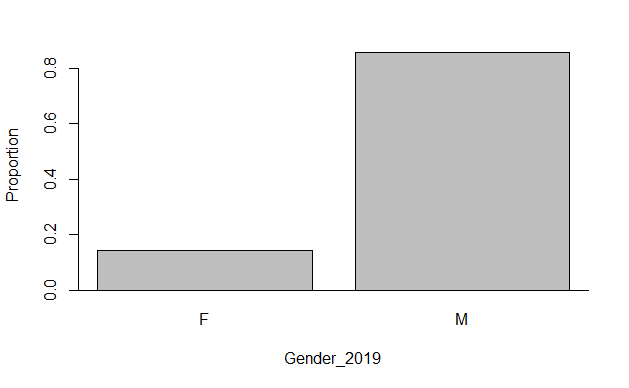

In 2019 Gender category of gun death consists of 14.26% females and 85.73% males.

*Figure 6. Bar plots with percent of gun deaths in ethnic groups category in 2019.*

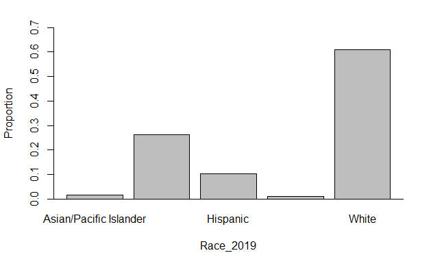

In 2019 race category 60.98% white, 26.21% black, 10.22% hispanic, 1.61% Asian/Pacific Islander and 0.97% Native American/Native Alaskan gun deaths took place.

*Figure 7. Bar plots with percent of gun deaths in intent category in 2012 and 2019.*

### Description

This report will answer the question 7 of project A.

```r
# I put the frequencies and proportions of gun deaths by intent by year.

cbind(Intent_2012, Intent_2019)
```

```
             Intent_2012 Intent_2019
Accidental           548         486
Homicide           12093       14909
Suicide            20666       23941
Undetermined         256         346
```

```r
cbind(Intent.props_2012, Intent.props_2019)
```

```
             Intent.props_2012 Intent.props_2019
Accidental         0.016327504       0.012247367
Homicide           0.360307481       0.375711910
Suicide            0.615737568       0.603321405
Undetermined       0.007627447       0.008719319
```

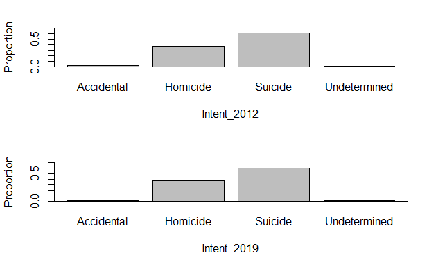

From the barplot no discernible significant changes in intent of gun death from 2012 to 2019.

*Figure 8. Bar plots with percent of gun deaths in gender category in 2012 and 2019.*

```r
# I put the frequencies and proportions of gun deaths by intent by year.

cbind(Gender_2012, Gender_2019)
```

```
  Gender_2012 Gender_2019
F        4725        5666
M       28838       34041
```

```r
cbind(Gender.props_2012, Gender.props_2019)
```

```
  Gender.props_2012 Gender.props_2019
F           0.14078         0.1426952
M           0.85922         0.8573048
```

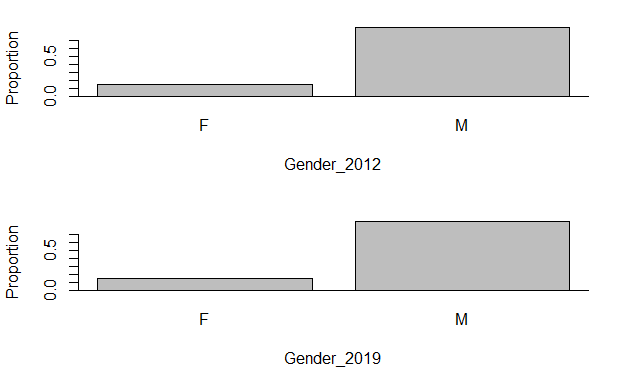

No big changes by observing the barplots.

*Figure 9. Bar plots with percent of gun deaths by race category in 2012 and 2019.*

```r
# I put the frequencies and proportions of gun deaths by intent by year.

cbind(Race_2012, Race_2019)
```

```
                               Race_2012 Race_2019
Asian/Pacific Islander               453       641
Black                               7946     10410
Hispanic                            3061      4058
Native American/Native Alaskan       310       386
White                              21793     24212
```

```r
cbind(Race.props_2012, Race.props_2019)
```

```
                               Race.props_2012 Race.props_2019
Asian/Pacific Islander             0.013497006     0.016143249
Black                              0.236748801     0.262170398
Hispanic                           0.091201621     0.102198605
Native American/Native Alaskan     0.009236361     0.009721208
White                              0.649316211     0.609766540
```

[figure not shown]

### Conclusions

This project asked to look at selected variables Intent, gender and race for 2012 and 2019 gun death data individually and also comparing them side by side.

Individually both 2012 and 2019 showed with variable intent of gun deaths that suicide was the highest category with 61.57% and followed by Homicide at 36.03%. The 2019 data also shows Suicide in highest category with 60.33% followed by Homicide at 37.57%.

Gender variable shows both 2012 and 2019 Male is in majority with gun death at 85.92% and 85.73% respectively and Female with 14.08% and 14.26% respectively.

Race variable in 2012 and 2019 the gun death White was the highest 64.93% and 60.98% respectively. Black was next highest gun deaths with 23.67% and 26.22% respectively in 2012 and 2019.

In conclusion this would be a preliminary analysis and there is much more to be looked at depth in future analysis.